# SKU Similarity Efficiency in Multi-Container Assignments

## Executive Summary

This analysis evaluates the effectiveness of assignment batching in warehouse operations by measuring similarity between containers within each assignment.

Key findings include:

- **Low overall similarity**: Average SKU similarity across assignments is approximately 12.5%, indicating weak clustering.
- **High inefficiency prevalence**: ~76% of assignments contain at least one poorly matched container.
- **Performance impact**: Higher similarity is associated with faster completion times and reduced variability.
- **Location matters as much as SKU**: Physical proximity (location similarity) is as influential as SKU similarity in determining efficiency.
- **Consignment grouping is ineffective**: Assignments grouped by consignment do not show improved similarity or performance.

These findings suggest that current assignment logic can be significantly improved by incorporating both SKU and location-based clustering.

## Background

In warehouse operations, each LLOP (Low-Level Order Picker) assignment consists of **three containers (cages)** grouped under a single assignment identifier (LIST_ID).

Although these containers are picked together, they may:

- Belong to different consignments (customers)
- Be delivered to different loading lanes

The intended picking strategy is to **cluster similar SKUs within the same assignment** to:

- Reduce travel distance
- Improve picking efficiency
- Enable faster completion

However, there is currently limited visibility into how effectively this clustering is achieved in practice.

## Problem Statement

The current assignment process does not provide clear insight into how similar containers are within the same assignment.

This creates several potential inefficiencies:

- Containers with low SKU overlap may require pickers to travel across multiple locations
- Poor clustering can lead to inefficient pick paths
- Assignments may take longer to complete due to fragmented work
- Some containers may remain incomplete longer, delaying overall completion

This analysis aims to quantify and evaluate these inefficiencies.

## Key Analytical Questions

The analysis is designed to answer the following:

1. What is the percentage similarity of SKUs between containers within each assignment?
2. How does similarity vary depending on consignment structure?
   - All 3 containers from different consignments
   - 2 containers from one consignment and 1 from another
3. Are higher similarity scores linked to:
   - Faster assignment completion?
   - Reduced picker travel (approximated through location similarity)?
4. What proportion of assignments show low similarity and may indicate inefficiency?

```python
import pandas as pd
import matplotlib.pyplot as plt
import seaborn as sns

plt.style.use('seaborn-v0_8')
sns.set_context("talk")
```

## Data Overview

The dataset contains picking activity records, including:

- LIST_ID: Assignment identifier
- CONTAINER_ID: Container within assignment
- SKU_ID: Product identifier
- CONSIGNMENT: Customer grouping
- FROM_LOC_ID: Pick location
- DSTAMP: Timestamp of activity

Each valid assignment should contain exactly 3 containers.

```python
columns = [
"LIST_ID","CONTAINER_ID","SKU_ID","CONSIGNMENT",
"FROM_LOC_ID","DSTAMP","CODE","TO_LOC"
]

df = pd.read_csv(
"extract.csv",
names=columns,
dtype=str,
usecols=["LIST_ID","CONTAINER_ID","SKU_ID","CONSIGNMENT","FROM_LOC_ID","DSTAMP"]
)

df.shape
```

```
(3264126, 6)
```

## Data Preparation & Business Logic

To ensure consistent comparison:

- Only assignments with exactly **3 containers** are retained
- SKU sets are compared across these containers
- Location information is used to approximate travel efficiency

Additional features:

- **Aisle**: derived from location
- **Consignment group**: derived for classification purposes

```python
container_counts = df.groupby('LIST_ID')['CONTAINER_ID'].nunique()

valid_lists = container_counts[container_counts == 3].index
df = df[df['LIST_ID'].isin(valid_lists)]

df['aisle'] = df['FROM_LOC_ID'].str[:2]
df['consignment_group'] = df['CONSIGNMENT'].str[:4]
```

## Methodology

Similarity is measured using **Jaccard similarity**:

J(A, B) = |A ∩ B| / |A ∪ B|

Applied to:

- SKU sets (product overlap)
- Location sets (spatial proximity)
- Aisle sets (coarse spatial grouping)

For each assignment:

- Pairwise similarity is calculated across 3 containers
- Aggregated metrics include:
- Average similarity → overall clustering
- Minimum similarity → identifies poorest match (key inefficiency signal)

Minimum similarity highlights assignments with at least one poorly matched container.

```python
container_data = (
df.groupby(['LIST_ID','CONTAINER_ID'])
.agg({
'SKU_ID': lambda x: set(x),
'FROM_LOC_ID': lambda x: set(x),
'aisle': lambda x: set(x),
'consignment_group':'first'
})
.reset_index()
)
```

```python
from itertools import combinations

def jaccard(a,b):
    return len(a & b)/len(a | b) if a | b else 0

results = []

for list_id, group in container_data.groupby('LIST_ID'):

    records = group.to_dict('records')

    sims_sku = []
    sims_loc = []
    sims_aisle = []

    for c1, c2 in combinations(records, 2):
        sims_sku.append(jaccard(c1['SKU_ID'], c2['SKU_ID']))
        sims_loc.append(jaccard(c1['FROM_LOC_ID'], c2['FROM_LOC_ID']))
        sims_aisle.append(jaccard(c1['aisle'], c2['aisle']))

    results.append({
        'LIST_ID': list_id,
        'avg_sku_similarity': sum(sims_sku)/3,
        'avg_location_similarity': sum(sims_loc)/3,
        'avg_aisle_similarity': sum(sims_aisle)/3,
        'min_sku_similarity': min(sims_sku),
        'min_location_similarity': min(sims_loc),
        'min_aisle_similarity': min(sims_aisle)
    })

results_df = pd.DataFrame(results)
results_df.describe()
```

|  | avg_sku_similarity | avg_location_similarity | avg_aisle_similarity | min_sku_similarity | min_location_similarity | min_aisle_similarity |
| --- | --- | --- | --- | --- | --- | --- |
| count | 37659.000000 | 37659.000000 | 37659.000000 | 37659.000000 | 37659.000000 | 37659.000000 |
| mean | 0.124700 | 0.116154 | 0.560911 | 0.075637 | 0.068463 | 0.428387 |
| std | 0.138874 | 0.127518 | 0.246040 | 0.136246 | 0.125683 | 0.291046 |
| min | 0.000000 | 0.000000 | 0.000000 | 0.000000 | 0.000000 | 0.000000 |
| 25% | 0.061035 | 0.057213 | 0.388889 | 0.000000 | 0.000000 | 0.208333 |
| 50% | 0.098261 | 0.093059 | 0.555556 | 0.047619 | 0.043478 | 0.400000 |
| 75% | 0.143928 | 0.137546 | 0.714286 | 0.095238 | 0.088235 | 0.600000 |
| max | 1.000000 | 1.000000 | 1.000000 | 1.000000 | 1.000000 | 1.000000 |

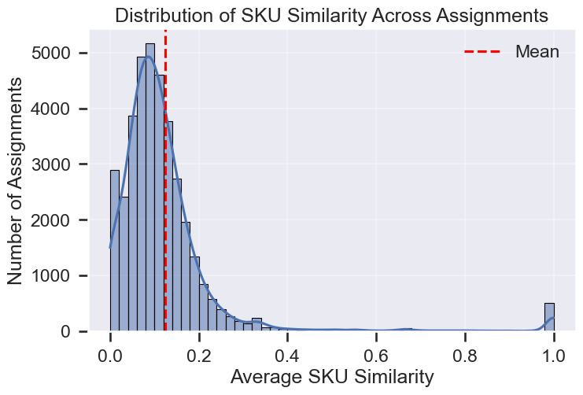

```python
plt.figure(figsize=(8,5))
sns.histplot(results_df['avg_sku_similarity'], bins=50, kde=True)

plt.title("Distribution of SKU Similarity Across Assignments")
plt.xlabel("Average SKU Similarity")
plt.ylabel("Number of Assignments")

plt.axvline(
    results_df['avg_sku_similarity'].mean(),
    color='red',
    linestyle='--',
    label='Mean'
)

plt.legend()
plt.grid(alpha=0.3)
plt.show()
```

## Assignment Duration

```python
df['DSTAMP'] = pd.to_datetime(
df['DSTAMP'],
format='%d-%b-%y %I.%M.%S.%f %p',
errors='coerce'
)

times = df.groupby('LIST_ID')['DSTAMP'].agg(['min','max'])

times['duration_sec'] = (times['max'] - times['min']).dt.total_seconds()

results_df = results_df.merge(times[['duration_sec']], left_on='LIST_ID', right_index=True)

results_df = results_df[results_df['duration_sec']>0]
results_df = results_df[results_df['duration_sec'] < results_df['duration_sec'].quantile(0.99)]
```

## Similarity vs Performance

A negative relationship between similarity and duration indicates that better clustering leads to faster completion.

```python
print(results_df[['avg_sku_similarity','duration_sec']].corr())
print(results_df[['avg_location_similarity','duration_sec']].corr())
print(results_df[['avg_aisle_similarity','duration_sec']].corr())
```

```
                    avg_sku_similarity  duration_sec
avg_sku_similarity            1.000000     -0.255278
duration_sec                 -0.255278      1.000000
                         avg_location_similarity  duration_sec
avg_location_similarity                  1.00000      -0.25575
duration_sec                            -0.25575       1.00000
                      avg_aisle_similarity  duration_sec
avg_aisle_similarity              1.000000     -0.167825
duration_sec                     -0.167825      1.000000
```

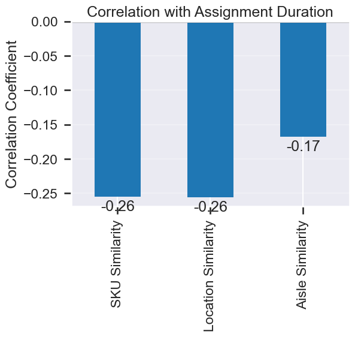

```python
corrs = {
    'SKU Similarity': results_df[['avg_sku_similarity','duration_sec']].corr().iloc[0,1],
    'Location Similarity': results_df[['avg_location_similarity','duration_sec']].corr().iloc[0,1],
    'Aisle Similarity': results_df[['avg_aisle_similarity','duration_sec']].corr().iloc[0,1]
}

plt.figure(figsize=(6,4))
pd.Series(corrs).plot(kind='bar', color='#1f77b4')

plt.title("Correlation with Assignment Duration")
plt.ylabel("Correlation Coefficient")

plt.axhline(0, color='black')

for i, v in enumerate(corrs.values()):
    plt.text(i, v - 0.02, f"{v:.2f}", ha='center')

plt.grid(axis='y', alpha=0.3)
plt.show()
```

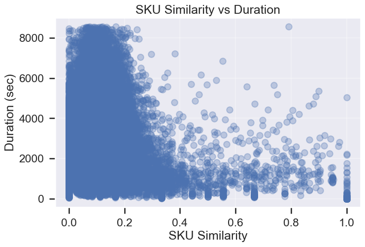

```python
plt.figure(figsize=(8,5))
plt.scatter(results_df['avg_sku_similarity'], results_df['duration_sec'], alpha=0.3)
plt.xlabel("SKU Similarity")
plt.ylabel("Duration (sec)")
plt.title("SKU Similarity vs Duration")
plt.grid(alpha=0.3)
plt.show()
```

## Similarity Bucket Analysis

Assignments are grouped into similarity buckets to compare performance across clustering levels.

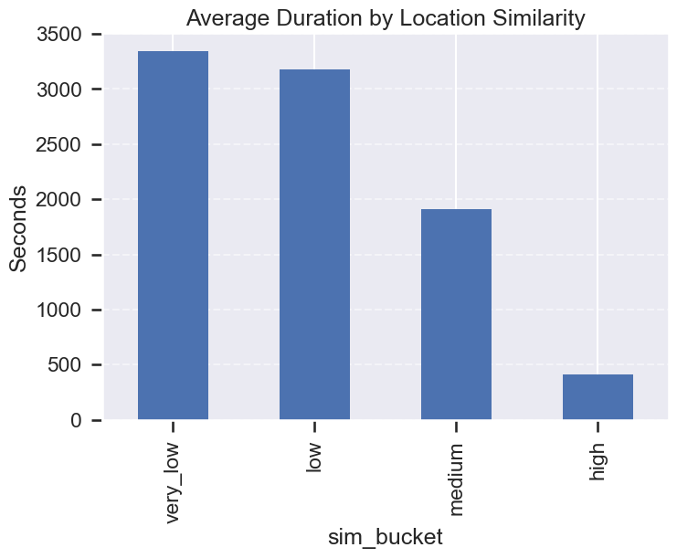

```python
results_df['sim_bucket'] = pd.cut(
results_df['avg_location_similarity'],
bins=[0,0.1,0.2,0.4,1],
labels=['very_low','low','medium','high']
)

bucket_means = results_df.groupby('sim_bucket')['duration_sec'].mean()

bucket_means.plot(kind='bar')
plt.title("Average Duration by Location Similarity")
plt.ylabel("Seconds")
plt.grid(axis='y', linestyle='--', alpha=0.5)
plt.show()
```

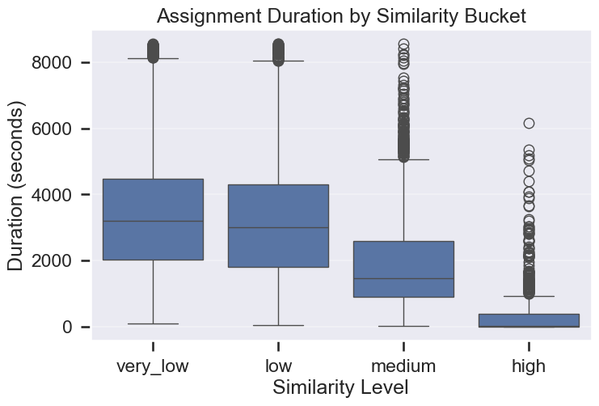

```python
plt.figure(figsize=(8,5))

sns.boxplot(
    x='sim_bucket',
    y='duration_sec',
    data=results_df,
    order=['very_low','low','medium','high']
)

plt.title("Assignment Duration by Similarity Bucket")
plt.xlabel("Similarity Level")
plt.ylabel("Duration (seconds)")

plt.grid(axis='y', alpha=0.3)
plt.show()
```

## Low Similarity Assignments

Assignments below a similarity threshold are considered inefficient.

```python
threshold = 0.1
results_df['low_similarity'] = results_df['min_sku_similarity'] < threshold

results_df['low_similarity'].mean()
```

```
np.float64(0.7654095810310606)
```

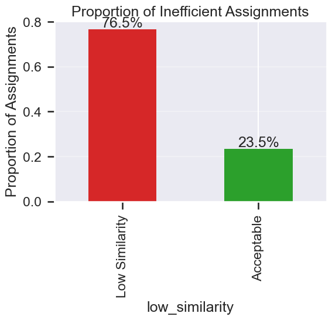

```python
plt.figure(figsize=(6,4))

results_df['low_similarity'].value_counts(normalize=True).plot(
    kind='bar',
    color=['#d62728','#2ca02c']
)

plt.xticks([0,1], ['Low Similarity','Acceptable'])
plt.ylabel("Proportion of Assignments")
plt.title("Proportion of Inefficient Assignments")

for i, v in enumerate(results_df['low_similarity'].value_counts(normalize=True)):
    plt.text(i, v + 0.01, f"{v:.1%}", ha='center')

plt.grid(axis='y', alpha=0.3)
plt.show()
```

## Consignment Analysis

Assignments are classified by the number of unique consignments to assess structural impact on similarity and performance.

```python
consignment_counts = df.groupby('LIST_ID')['consignment_group'].nunique()

consignment_type = consignment_counts.map({
    1:'all_same',
    2:'2_and_1',
    3:'all_different'
})

results_df = results_df.merge(consignment_type.rename('consignment_type'),
                              left_on='LIST_ID', right_index=True)

results_df.groupby('consignment_type')['avg_sku_similarity'].mean()
results_df.groupby('consignment_type')['duration_sec'].mean()
```

```
consignment_type
2_and_1          2928.714194
all_different    2950.111744
all_same         3102.077822
Name: duration_sec, dtype: float64
```

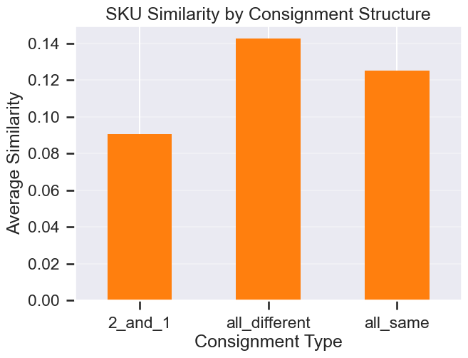

```python
plt.figure(figsize=(7,5))

results_df.groupby('consignment_type')['avg_sku_similarity'].mean().plot(
    kind='bar',
    color='#ff7f0e'
)

plt.title("SKU Similarity by Consignment Structure")
plt.ylabel("Average Similarity")
plt.xlabel("Consignment Type")

plt.xticks(rotation=0)
plt.grid(axis='y', alpha=0.3)
plt.show()
```

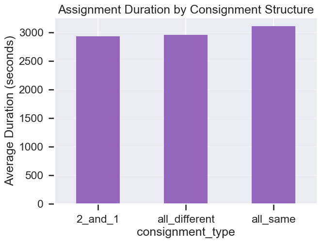

```python
plt.figure(figsize=(7,5))

results_df.groupby('consignment_type')['duration_sec'].mean().plot(
    kind='bar',
    color='#9467bd'
)

plt.title("Assignment Duration by Consignment Structure")
plt.ylabel("Average Duration (seconds)")

plt.xticks(rotation=0)
plt.grid(axis='y', alpha=0.3)
plt.show()
```

## Key Findings & Answers

**1. SKU Similarity**

- Average similarity is low (~12%), indicating weak clustering

**2. Consignment Structure**

- No clear improvement from grouping by consignment
- Consignment does not align with SKU similarity

**3. Performance Relationship**

- Higher similarity leads to faster completion
- Lower similarity results in slower and less predictable performance

**4. Travel Efficiency (Proxy)**

- Location similarity correlates similarly to SKU similarity
- Indicates spatial clustering is critical for efficiency

**5. Inefficiency Prevalence**

- ~76% of assignments contain at least one poorly matched container

## Limitations

This analysis does not include direct measurement of travel distance.

Instead, **location similarity is used as a proxy** for spatial efficiency.

Limitations include:

- No exact travel paths
- No warehouse layout constraints
- No congestion modelling

## Conclusion & Recommendations

Assignments are currently **not optimally structured**, with widespread low similarity.

**Key implications**:

- Poor clustering drives inefficiency
- Location matters as much as SKU
- Consignment grouping is ineffective

**Recommendations:**

- Optimise assignments using location proximity
- Combine SKU and spatial clustering
- Reduce low-similarity assignments

**Further Work:**

- Incorporate travel distance data
- Analyse pick path optimisation
- Improve assignment algorithms